# 01_Goodreads

## Goodreads Exploration

Exploratory data analysis of book reviews on [Goodreads](https://www.goodreads.com/)

### Preliminary Questions

- Which books have the highest ratings?
- What does the distribution of ratings look like?
- Which have been rated the most?
- Do older books have higher ratings and more ratings than newer books?

#### Other Questions to Consider (need new dataset)

More F or M users? Do F or M authors receive higher ratings/more ratings? Do F users give F authors higher ratings (compared to F-M, M-F, M-M)? Same questions for genres. Same questions for years (do F or M rate older books higher/more often)? Age (older rate books differently)? Are older people leaving more reviews?

```python
import numpy as np
import scipy as sp
import matplotlib as mpl
import matplotlib.cm as cm
import matplotlib.pyplot as plt
import pandas as pd
import seaborn as sns
```

### 1. Read Data

from CSV of 6000 books scraped from Goodreads

```python
df=pd.read_csv("./data/goodreads.csv", header=None,
               names=["rating", 'review_count', 'isbn', 'booktype','author_url', 'year',
                      'genre_urls', 'dir','rating_count', 'name'],
)
df.head()
```

|  | rating | review_count | isbn | booktype | author_url | year | genre_urls | dir | rating_count | name |
| --- | --- | --- | --- | --- | --- | --- | --- | --- | --- | --- |
| 0 | 4.40 | 136455 | 0439023483 | good_reads:book | https://www.goodreads.com/author/show/153394.S... | 2008.0 | /genres/young-adult\|/genres/science-fiction\|/g... | dir01/2767052-the-hunger-games.html | 2958974 | The Hunger Games (The Hunger Games, #1) |
| 1 | 4.41 | 16648 | 0439358078 | good_reads:book | https://www.goodreads.com/author/show/1077326.... | 2003.0 | /genres/fantasy\|/genres/young-adult\|/genres/fi... | dir01/2.Harry_Potter_and_the_Order_of_the_Phoe... | 1284478 | Harry Potter and the Order of the Phoenix (Har... |
| 2 | 3.56 | 85746 | 0316015849 | good_reads:book | https://www.goodreads.com/author/show/941441.S... | 2005.0 | /genres/young-adult\|/genres/fantasy\|/genres/ro... | dir01/41865.Twilight.html | 2579564 | Twilight (Twilight, #1) |
| 3 | 4.23 | 47906 | 0061120081 | good_reads:book | https://www.goodreads.com/author/show/1825.Har... | 1960.0 | /genres/classics\|/genres/fiction\|/genres/histo... | dir01/2657.To_Kill_a_Mockingbird.html | 2078123 | To Kill a Mockingbird |
| 4 | 4.23 | 34772 | 0679783261 | good_reads:book | https://www.goodreads.com/author/show/1265.Jan... | 1813.0 | /genres/classics\|/genres/fiction\|/genres/roman... | dir01/1885.Pride_and_Prejudice.html | 1388992 | Pride and Prejudice |

```python
df.shape
```

```
(6000, 10)
```

df contains 6000 rows and 10 columns. Each row shows aggregate information for 1 book, including the average rating, total number of reviews, genre(s), and year published.

### 2. Cleaning and Prep

#### a. Remove rows with null values

After further exploration of **booktype**, I found that there were some rows containing None and null values. These should be removed from my analysis.

```python
df.loc[df["booktype"] != "good_reads:book"]
```

|  | rating | review_count | isbn | booktype | author_url | year | genre_urls | dir | rating_count | name |
| --- | --- | --- | --- | --- | --- | --- | --- | --- | --- | --- |
| 3643 | NaN | None | None | None | None | NaN | NaN | dir37/9658936-harry-potter.html | None | None |
| 5282 | NaN | None | None | None | None | NaN | NaN | dir53/113138.The_Winner.html | None | None |

```python
# remove null rows
df = df.loc[df["isbn"] != "None"]
```

```python
df.shape
```

```
(5998, 10)
```

The data frame now contains 5998 rows after removing the 2 null rows.

#### b. Remove rows with null years

```python
df = df[df.year.notnull()]
df.shape
```

```
(5993, 10)
```

Removing the null years removes an additional 5 rows.

#### c. Convert data types

We can now convert year to an int and will also convert counts to int.

```python
df["year"]=df["year"].astype(int)
df["review_count"] = df["review_count"].astype(int)
df["rating_count"] = df["rating_count"].astype(int)
```

#### d. Remove books with 0 reviews

```python
df = df.loc[df["review_count"] > 0]
```

```python
df.shape
```

```
(5985, 10)
```

That removed another 8 rows.

### 3. Querying and Initial Exploration

#### a. Explore rating distributions

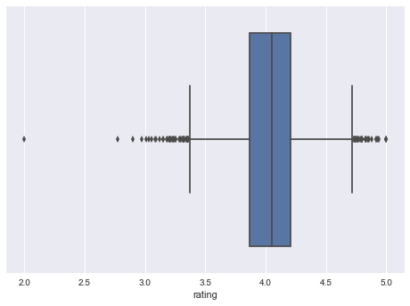

```python
sns.boxplot(df.rating)
plt.show()
```

```python
df.rating.mean()
```

```
4.041191311612362
```

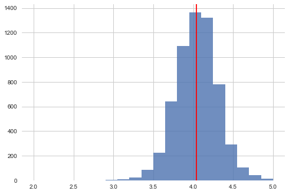

```python
with sns.axes_style("whitegrid"):
    df.rating.hist(bins=20, alpha=0.8);
    sns.despine(left=True, bottom=True, right=True)
    plt.axvline(df.rating.mean(), color='r')
    plt.show()
```

Most of the ratings are just above 4 — the mean is 4.04.  
What is the percentage of ratings above/below 4. How many are less than 3? How many are a perfect 5?

```python
np.sum(df.rating > 4) / df.shape[0]
```

```
0.56274018379281532
```

```python
np.sum(df.rating < 3)
```

```
4
```

```python
np.sum(df.rating == 5)
```

```
3
```

#### b. Books with the highest/lowest ratings

Lowest

```python
df.loc[df['rating'].idxmin()]
```

```
rating                                                          2
review_count                                                  368
isbn                                                   0983650322
booktype                                          good_reads:book
author_url      https://www.goodreads.com/author/show/9414.Vic...
year                                                         2011
genre_urls      /genres/young-adult|/genres/science-fiction|/g...
dir                            dir38/12393909-revealing-eden.html
rating_count                                                  688
name                         Revealing Eden (Save the Pearls, #1)
Name: 3738, dtype: object
```

Highest

```python
df.loc[df['rating'].idxmax()]
```

```
rating                                                          5
review_count                                                   28
isbn                                                          NaN
booktype                                          good_reads:book
author_url      https://www.goodreads.com/author/show/6467808....
year                                                         2014
genre_urls                       /genres/poetry|/genres/childrens
dir                dir18/22204746-an-elephant-is-on-my-house.html
rating_count                                                   64
name                                   An Elephant Is On My House
Name: 1718, dtype: object
```

Only 4 books in the sample have average ratings under 3. The lowest rated book is *Revealing Eden*. Also in the bottom 4, no surprise, is Hitler's *Mein Kampf*.

```python
df.query("rating < 3")
```

|  | rating | review_count | isbn | booktype | author_url | year | genre_urls | dir | rating_count | name |
| --- | --- | --- | --- | --- | --- | --- | --- | --- | --- | --- |
| 2609 | 2.90 | 8 | NaN | good_reads:book | https://www.goodreads.com/author/show/7707820.... | 2013 | /genres/romance\|/genres/realistic-fiction\|/gen... | dir27/19546932-how-to-be-a-perfect-girl.html | 31 | How To Be A Perfect Girl |
| 3738 | 2.00 | 368 | 0983650322 | good_reads:book | https://www.goodreads.com/author/show/9414.Vic... | 2011 | /genres/young-adult\|/genres/science-fiction\|/g... | dir38/12393909-revealing-eden.html | 688 | Revealing Eden (Save the Pearls, #1) |
| 5844 | 2.97 | 1399 | 0395083621 | good_reads:book | https://www.goodreads.com/author/show/30691.Ad... | 1925 | /genres/history\|/genres/non-fiction\|/genres/bi... | dir59/54270.Mein_Kampf.html | 12417 | Mein Kampf |
| 5979 | 2.77 | 800 | 0060988649 | good_reads:book | https://www.goodreads.com/author/show/7025.Gre... | 2001 | /genres/fantasy\|/genres/fiction\|/genres/myster... | dir60/24929.Lost.html | 11128 | Lost |

3 books have a perfect rating of 5. These have very low review counts.

```python
df.query("rating == 5")
```

|  | rating | review_count | isbn | booktype | author_url | year | genre_urls | dir | rating_count | name |
| --- | --- | --- | --- | --- | --- | --- | --- | --- | --- | --- |
| 1718 | 5.0 | 28 | NaN | good_reads:book | https://www.goodreads.com/author/show/6467808.... | 2014 | /genres/poetry\|/genres/childrens | dir18/22204746-an-elephant-is-on-my-house.html | 64 | An Elephant Is On My House |
| 2145 | 5.0 | 3 | 1300589469 | good_reads:book | https://www.goodreads.com/author/show/6906561.... | 2012 | NaN | dir22/17287259-a-book-about-absolutely-nothing... | 63 | A Book About Absolutely Nothing. |
| 5564 | 5.0 | 9 | NaN | good_reads:book | https://www.goodreads.com/author/show/7738947.... | 2014 | /genres/romance\|/genres/new-adult | dir56/21902777-untainted.html | 14 | Untainted (Photographer Trilogy, #3) |

There is only 1 book with a rating > 4.75 and more than 1000 reviews - *Words of Radiance*.

```python
df[(df.rating > 4.75) & (df.review_count > 1000)]
```

|  | rating | review_count | isbn | booktype | author_url | year | genre_urls | dir | rating_count | name |
| --- | --- | --- | --- | --- | --- | --- | --- | --- | --- | --- |
| 1595 | 4.76 | 3361 | 0765326361 | good_reads:book | https://www.goodreads.com/author/show/38550.Br... | 2014 | /genres/fantasy\|/genres/fantasy\|/genres/epic-f... | dir16/17332218-words-of-radiance.html | 32304 | Words of Radiance (The Stormlight Archive, #2) |

#### c. Oldest book

```python
df.loc[df['year'].idxmin()]
```

```
rating                                                        3.6
review_count                                                 1644
isbn                                                   0141026286
booktype                                          good_reads:book
author_url      https://www.goodreads.com/author/show/5158478....
year                                                        -1500
genre_urls      /genres/religion|/genres/literature|/genres/an...
dir                        dir14/19351.The_Epic_of_Gilgamesh.html
rating_count                                                42026
name                                        The Epic of Gilgamesh
Name: 1398, dtype: object
```

#### d. Most reviews

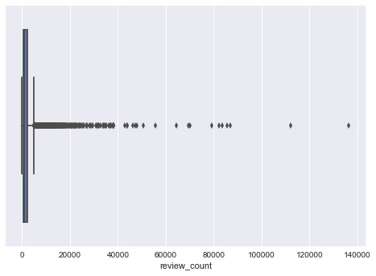

```python
sns.boxplot(df.review_count)
plt.show()
```

```python
df.review_count.mean()
```

```
2377.5049289891394
```

Most books have around 2000 reviews. Only a few outliers have more than 100,000.

```python
df.loc[df['review_count'].idxmax()]
```

```
rating                                                        4.4
review_count                                               136455
isbn                                                   0439023483
booktype                                          good_reads:book
author_url      https://www.goodreads.com/author/show/153394.S...
year                                                         2008
genre_urls      /genres/young-adult|/genres/science-fiction|/g...
dir                           dir01/2767052-the-hunger-games.html
rating_count                                              2958974
name                      The Hunger Games (The Hunger Games, #1)
Name: 0, dtype: object
```

*The Hunger Games (#1)* is the most reviewed book in the sample.

```python
df[df.review_count > 80000]
```

|  | rating | review_count | isbn | booktype | author_url | year | genre_urls | dir | rating_count | name |
| --- | --- | --- | --- | --- | --- | --- | --- | --- | --- | --- |
| 0 | 4.40 | 136455 | 0439023483 | good_reads:book | https://www.goodreads.com/author/show/153394.S... | 2008 | /genres/young-adult\|/genres/science-fiction\|/g... | dir01/2767052-the-hunger-games.html | 2958974 | The Hunger Games (The Hunger Games, #1) |
| 2 | 3.56 | 85746 | 0316015849 | good_reads:book | https://www.goodreads.com/author/show/941441.S... | 2005 | /genres/young-adult\|/genres/fantasy\|/genres/ro... | dir01/41865.Twilight.html | 2579564 | Twilight (Twilight, #1) |
| 26 | 4.43 | 112279 | 0525478817 | good_reads:book | https://www.goodreads.com/author/show/1406384.... | 2012 | /genres/young-adult\|/genres/book-club\|/genres/... | dir01/11870085-the-fault-in-our-stars.html | 1150626 | The Fault in Our Stars |
| 43 | 4.34 | 82098 | 0062024035 | good_reads:book | https://www.goodreads.com/author/show/4039811.... | 2011 | /genres/young-adult\|/genres/science-fiction\|/g... | dir01/13335037-divergent.html | 1127983 | Divergent (Divergent, #1) |
| 571 | 3.94 | 87076 | 0307588378 | good_reads:book | https://www.goodreads.com/author/show/2383.Gil... | 2012 | /genres/fiction\|/genres/mystery\|/genres/book-c... | dir06/19288043-gone-girl.html | 682110 | Gone Girl |
| 1841 | 4.03 | 83643 | 0439023513 | good_reads:book | https://www.goodreads.com/author/show/153394.S... | 2010 | /genres/young-adult\|/genres/science-fiction\|/g... | dir19/7260188-mockingjay.html | 1316704 | Mockingjay (The Hunger Games, #3) |

There are 6 books that have more than 80,000 reviews. *The Fault in Our Stars* has the 2nd most reviews and released later than the most reviewed.

### 4. Visualization

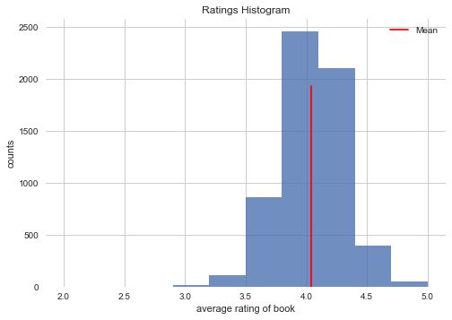

```python
meanrat=df.rating.mean()
with sns.axes_style("whitegrid"):
    df.rating.hist(bins=10, alpha=0.8);
    sns.despine(left=True, bottom=True, right=True)
    plt.axvline(meanrat, 0, 0.75, color='r', label='Mean')
    plt.xlabel("average rating of book")
    plt.ylabel("counts")
    plt.title("Ratings Histogram")
    plt.legend()
    plt.show()
```

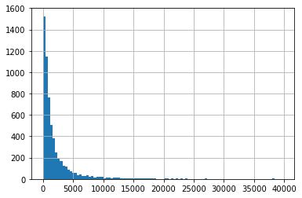

```python
df.review_count.hist(bins=np.arange(0, 40000, 400))
plt.show()
```

Rescale x-axis to be logarithmic to more easily see structure

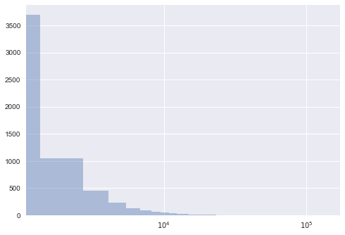

```python
df.review_count.hist(bins=100, alpha=0.4)
plt.xscale("log");
plt.show()
```

Another way to show

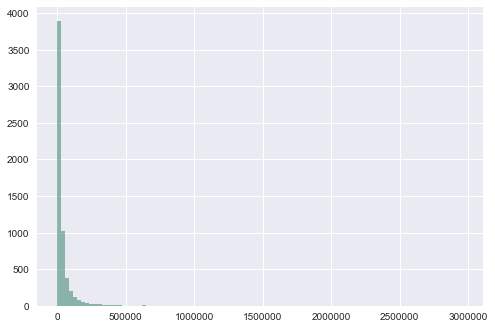

```python
plt.hist(df.rating_count.values, bins=100, alpha=0.4)
plt.show()
```

Scatterplot in matplotlib of rating against year. By setting the alpha transparency low we can how the density of highly rated books on goodreads has changed.

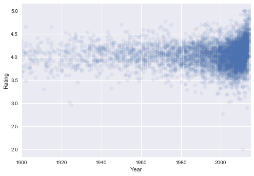

```python
plt.scatter(df.year, df.rating, alpha=.08)
plt.xlim([1900,2015])
plt.xlabel("Year")
plt.ylabel("Rating")
plt.show()
```

### Numpy Arrays

```python
alist = [1,2,3,4,5]
```

```python
alist + alist
```

```
[1, 2, 3, 4, 5, 1, 2, 3, 4, 5]
```

```python
np.array(alist) + np.array(alist)
```

```
array([ 2,  4,  6,  8, 10])
```

```python
np.array(alist)**2
```

```
array([ 1,  4,  9, 16, 25])
```

```python
a=np.array([1,2,3,4,5])
b=np.array([1,2,3,4,5])
print(a+b)
```

```
[ 2  4  6  8 10]
```

```python
a+1
```

```
array([2, 3, 4, 5, 6])
```

```python
print(a+1)
```

```
[2 3 4 5 6]
```

### All Together - Hamlet

Access Hamlet word by word - there are roughly 32,000 words in Hamlet

```python
with open("./data/hamlet.txt") as hamletfile:
    hamlettext=hamletfile.read()
    hamlettokens=hamlettext.split()
    print(len(hamlettokens))
```

```
31659
```

```python
hamletlctokens=[word.lower() for word in hamlettokens]
hamletlctokens.count("thou")
```

```
95
```

Find a unique set of words using python's 'set' data structure

```python
uniquelctokens=set(hamletlctokens)
```

```python
tokendict={}
for ut in uniquelctokens:
    tokendict[ut]=hamletlctokens.count(ut)
```

```python
tokendict['the']
```

```
1136
```

Find the 15 most used words

```python
freqwords = sorted(tokendict.items(), key=lambda item: -item[1])[:15]
freqwords
```

```
[('the', 1136),
 ('and', 943),
 ('to', 720),
 ('of', 667),
 ('a', 527),
 ('my', 512),
 ('i', 510),
 ('in', 420),
 ('you', 412),
 ('ham.', 358),
 ('that', 337),
 ('it', 324),
 ('is', 320),
 ('his', 295),
 ('not', 270)]
```

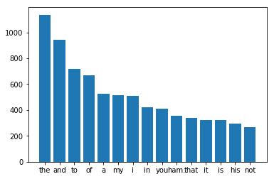

```python
pos = np.arange(len(freqwords))
plt.bar(pos, [e[1] for e in freqwords]);
plt.xticks(pos, [e[0] for e in freqwords]);
plt.show()
```